# ProjectWork_RsenalofData

Federico Pallesi, Tommaso Giannetti & Francesco Costa

2025-03-30

## Introduction

Welcome to our Data Analysis for Business project, coded in R. We are the **R-senal of Data** and we’re extremely proud to share our results after an intensive week of hardworking! 🚀🚀💪💪

During this coding journey we’ll summon from time to time a 4th member to our group, which will help us with coding some visualizations, improvements when reducing the full model and general debugging. His name is *CheatyGPT* 👾💻. Specifically AI took care of the following code chunks:

- *{r imputation-scatterplot}*
- *{r log-transformation}*
- *{r salary-econding}*
- *{r vglm-backward-loop}*

Coming to the project: the aim is to predict salary levels of baseball players using a dataset based on their individual performance statistics. Specifically, the dataset **Hitters** collects data about the 1986-87 season and observations range from in-game career stats to league and division metrics, as well as salary information. The main objective is to:

- **Transform the continuous salary variable into a categorical response**
- **Build a predictive model** capable of estimating a player’s salary level
- **Evaluate model’s performance** using randomly chosen cross-validation techniques
- **Improve the model** by selecting relevant predictors

## a. Generic Formulation of the Model

Multinomial logistic regression is used when the outcome variable is **categorical with more than two levels** ($K > 2$). It extends binary logistic regression by modeling the **log-odds** of each category relative to a **reference class**.

Let:

- $Y \in \{1, 2, ..., K\}$ be the categorical response variable
- $\mathbf{X} = (X_1, X_2, ..., X_p)$ be the vector of predictor variables
- $\beta_k$ be the coefficient vector for class $k$, for $k = 1, ..., K-1$ (assuming the $K$-th class as reference)

Then, the multinomial logistic model is expressed as:

$$\log \left( \frac{P(Y = k \mid \mathbf{X})}{P(Y = K \mid \mathbf{X})}
\right) = \beta_{k0} + \beta_{k1}X_1 + \beta_{k2}X_2 + \cdots +
\beta_{kp}X_p \quad \text{for } k = 1, ..., K-1$$

The model estimates one equation for each class $k$ (excluding the baseline class $K$), each representing the log-odds of being in class $k$ rather than in the reference class. In total, $K - 1$ equations are estimated simultaneously.

### How it Differs from Simple Logistic Regression

The table below summarizes the main differences between **binary logistic regression** and **multinomial logistic regression**:

| **Aspect** | **Binary Logistic Regression** | **Multinomial Logistic Regression** |
| --- | --- | --- |
| Outcome Variable | $Y \in \{0, 1\}$ | $Y \in \{1, 2, \dots, K\},\ K \geq 3$ |
| Log-Odds | One equation | $K - 1$ equations (each vs reference class) |
| Interpretation | Odds of class 1 vs class 0 | Odds of class $k$ vs class $K$ (reference) |
| Estimation | One coefficient vector $\boldsymbol{\beta}$ | $K - 1$ vectors $\boldsymbol{\beta}_1, \dots, \boldsymbol{\beta}_{K-1}$ |
| Link Function | Logistic / sigmoid | Softmax |
| Use Case | Binary classification problems | Multi-class classification (unordered classes) |

## b. Exploratory Data Analysis (EDA)

The **Hitters** dataset contains 20 variables for 317 professional baseball players. The first step to a successful EDA is to have a general overview of the **structure of the dataset**, to correctly **assign datatypes** to their corresponding variables and to **impute (if possible) missing values**. 👾 Looking at this section of the project you’ll notice that we’re working with copies of the dataset: this was due to our needs of a scaled and imputed versions of it specifically for the EDA. When it’s time to run models, you’ll see us working only with a cleaned version of the original dataset.

```r
library(ggplot2)
library(reshape2)
library(gridExtra)
library(corrplot)
```

### Load and inspect data

```r
Hitters <- read.csv("Hitters.csv", sep = ";")
str(Hitters)
```

```
## 'data.frame':    317 obs. of  20 variables:
##  $ AtBat    : int  293 315 479 496 321 594 185 298 323 574 ...
##  $ Hits     : int  66 81 130 141 87 169 37 73 81 159 ...
##  $ HmRun    : int  1 7 18 20 10 4 1 0 6 21 ...
##  $ Runs     : int  30 24 66 65 39 74 23 24 26 107 ...
##  $ RBI      : int  29 38 72 78 42 51 8 24 32 75 ...
##  $ Walks    : int  14 39 76 37 30 35 21 7 8 59 ...
##  $ Years    : int  1 14 3 11 2 11 2 3 2 10 ...
##  $ CAtBat   : int  293 3449 1624 5628 396 4408 214 509 341 4631 ...
##  $ CHits    : int  66 835 457 1575 101 1133 42 108 86 1300 ...
##  $ CHmRun   : int  1 69 63 225 12 19 1 0 6 90 ...
##  $ CRuns    : int  30 321 224 828 48 501 30 41 32 702 ...
##  $ CRBI     : int  29 414 266 838 46 336 9 37 34 504 ...
##  $ CWalks   : int  14 375 263 354 33 194 24 12 8 488 ...
##  $ League   : chr  "A" "N" "A" "N" ...
##  $ Division : chr  "E" "W" "W" "E" ...
##  $ PutOuts  : int  446 632 880 200 805 282 76 121 143 238 ...
##  $ Assists  : int  33 43 82 11 40 421 127 283 290 445 ...
##  $ Errors   : int  20 10 14 3 4 25 7 9 19 22 ...
##  $ Salary   : chr  NA "475" "480" "500" ...
##  $ NewLeague: chr  "A" "N" "A" "N" ...
```

```r
summary(Hitters)
```

```
##      AtBat            Hits           HmRun            Runs
##  Min.   : 16.0   Min.   :  1.0   Min.   : 0.00   Min.   :  0.00
##  1st Qu.:256.0   1st Qu.: 64.0   1st Qu.: 4.00   1st Qu.: 30.00
##  Median :379.0   Median : 96.0   Median : 8.00   Median : 48.00
##  Mean   :381.2   Mean   :101.1   Mean   :10.75   Mean   : 50.89
##  3rd Qu.:512.0   3rd Qu.:137.0   3rd Qu.:16.00   3rd Qu.: 69.00
##  Max.   :687.0   Max.   :238.0   Max.   :40.00   Max.   :130.00
##       RBI             Walks            Years            CAtBat
##  Min.   :  0.00   Min.   :  0.00   Min.   : 1.000   Min.   :   19
##  1st Qu.: 28.00   1st Qu.: 22.00   1st Qu.: 4.000   1st Qu.:  822
##  Median : 44.00   Median : 35.00   Median : 6.000   Median : 1928
##  Mean   : 47.95   Mean   : 38.51   Mean   : 7.429   Mean   : 2646
##  3rd Qu.: 63.00   3rd Qu.: 53.00   3rd Qu.:11.000   3rd Qu.: 3919
##  Max.   :121.00   Max.   :105.00   Max.   :24.000   Max.   :14053
##      CHits            CHmRun           CRuns             CRBI
##  Min.   :   4.0   Min.   :  0.00   Min.   :   1.0   Min.   :   0.0
##  1st Qu.: 209.0   1st Qu.: 14.00   1st Qu.: 101.0   1st Qu.:  91.0
##  Median : 506.0   Median : 37.00   Median : 247.0   Median : 219.0
##  Mean   : 717.3   Mean   : 68.94   Mean   : 358.1   Mean   : 328.8
##  3rd Qu.:1051.0   3rd Qu.: 90.00   3rd Qu.: 518.0   3rd Qu.: 421.0
##  Max.   :4256.0   Max.   :548.00   Max.   :2165.0   Max.   :1659.0
##      CWalks        League            Division            PutOuts
##  Min.   :   0   Length:317         Length:317         Min.   :   0.0
##  1st Qu.:  68   Class :character   Class :character   1st Qu.: 109.0
##  Median : 170   Mode  :character   Mode  :character   Median : 212.0
##  Mean   : 258                                         Mean   : 290.5
##  3rd Qu.: 337                                         3rd Qu.: 325.0
##  Max.   :1566                                         Max.   :1378.0
##     Assists          Errors          Salary           NewLeague
##  Min.   :  0.0   Min.   : 0.000   Length:317         Length:317
##  1st Qu.:  7.0   1st Qu.: 3.000   Class :character   Class :character
##  Median : 40.0   Median : 6.000   Mode  :character   Mode  :character
##  Mean   :107.9   Mean   : 8.091
##  3rd Qu.:166.0   3rd Qu.:11.000
##  Max.   :492.0   Max.   :32.000
```

```r
dim(Hitters)
```

```
## [1] 317  20
```

```r
# Convert Salary to numeric
Hitters$Salary <- as.numeric(Hitters$Salary)

# Convert categorical variables to factors
Hitters$League <- as.factor(Hitters$League)
Hitters$Division <- as.factor(Hitters$Division)
Hitters$NewLeague <- as.factor(Hitters$NewLeague)

str(Hitters)
```

```
## 'data.frame':    317 obs. of  20 variables:
##  $ AtBat    : int  293 315 479 496 321 594 185 298 323 574 ...
##  $ Hits     : int  66 81 130 141 87 169 37 73 81 159 ...
##  $ HmRun    : int  1 7 18 20 10 4 1 0 6 21 ...
##  $ Runs     : int  30 24 66 65 39 74 23 24 26 107 ...
##  $ RBI      : int  29 38 72 78 42 51 8 24 32 75 ...
##  $ Walks    : int  14 39 76 37 30 35 21 7 8 59 ...
##  $ Years    : int  1 14 3 11 2 11 2 3 2 10 ...
##  $ CAtBat   : int  293 3449 1624 5628 396 4408 214 509 341 4631 ...
##  $ CHits    : int  66 835 457 1575 101 1133 42 108 86 1300 ...
##  $ CHmRun   : int  1 69 63 225 12 19 1 0 6 90 ...
##  $ CRuns    : int  30 321 224 828 48 501 30 41 32 702 ...
##  $ CRBI     : int  29 414 266 838 46 336 9 37 34 504 ...
##  $ CWalks   : int  14 375 263 354 33 194 24 12 8 488 ...
##  $ League   : Factor w/ 2 levels "A","N": 1 2 1 2 2 1 2 1 2 1 ...
##  $ Division : Factor w/ 2 levels "E","W": 1 2 2 1 1 2 1 2 2 1 ...
##  $ PutOuts  : int  446 632 880 200 805 282 76 121 143 238 ...
##  $ Assists  : int  33 43 82 11 40 421 127 283 290 445 ...
##  $ Errors   : int  20 10 14 3 4 25 7 9 19 22 ...
##  $ Salary   : num  NA 475 480 500 91.5 ...
##  $ NewLeague: Factor w/ 2 levels "A","N": 1 2 1 2 2 1 1 1 2 1 ...
```

```r
# Check for missing values
colSums(is.na(Hitters))
```

```
##     AtBat      Hits     HmRun      Runs       RBI     Walks     Years    CAtBat
##         0         0         0         0         0         0         0         0
##     CHits    CHmRun     CRuns      CRBI    CWalks    League  Division   PutOuts
##         0         0         0         0         0         0         0         0
##   Assists    Errors    Salary NewLeague
##         0         0        64         0
```

```r
# Check for duplicated records
sum(duplicated(Hitters))
```

```
## [1] 0
```

### Handling missing values

After noticing a total of 64 NAs sitting in our predicting variable *Salary*, we decide to impute those missing values with **KNN-Imputer**. This imputation technique works that it selects the *K* nearest neighbors to the NA and then it computes the mean of those *K* observations. We went specifically with this technique as it preserves the distribution of the imputed variable.

```r
library(VIM)

# Impute missing values with KNN
Hitters_imputed <- kNN(Hitters, variable = "Salary", k = 5)

Hitters_imputed <- subset(Hitters_imputed, select = -Salary_imp)

Hitters <- Hitters_imputed

# Check if there are still missing values
colSums(is.na(Hitters))
```

```
##     AtBat      Hits     HmRun      Runs       RBI     Walks     Years    CAtBat
##         0         0         0         0         0         0         0         0
##     CHits    CHmRun     CRuns      CRBI    CWalks    League  Division   PutOuts
##         0         0         0         0         0         0         0         0
##   Assists    Errors    Salary NewLeague
##         0         0         0         0
```

```r
Hitters_clean <- Hitters
```

With this scatter plot we verify that KNN imputation doesn’t introduce excessive bias. This is not our case because the imputed values aren’t wrongly located.

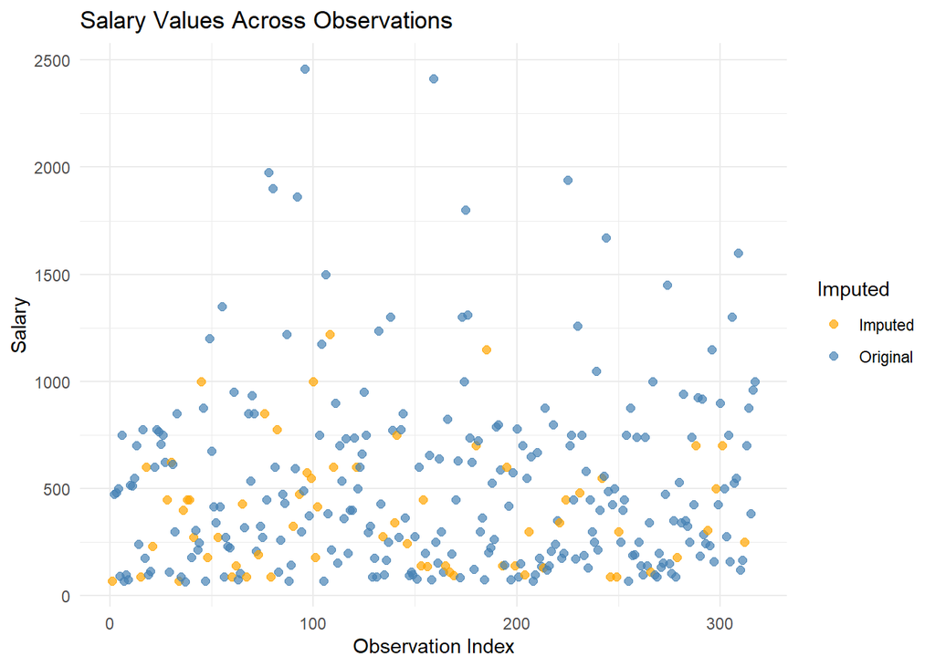

```r
Hitters_raw <- read.csv("Hitters.csv", sep = ";")
Hitters_raw$Salary <- as.numeric(Hitters_raw$Salary)

Hitters_imputed <- Hitters_clean

# Create label to mark imputed values
Hitters_imputed$Imputed <- ifelse(is.na(Hitters_raw$Salary), "Imputed", "Original")

Hitters_imputed$Index <- 1:nrow(Hitters_imputed)

ggplot(Hitters_imputed, aes(x = Index, y = Salary, color = Imputed)) +
  geom_point(size = 2, alpha = 0.7) +
  labs(
    title = "Salary Values Across Observations",
    x = "Observation Index",
    y = "Salary"
  ) +
  theme_minimal() +
  scale_color_manual(values = c("Original" = "steelblue", "Imputed" = "orange"))
```

### Distribution of Salary after KNN imputation

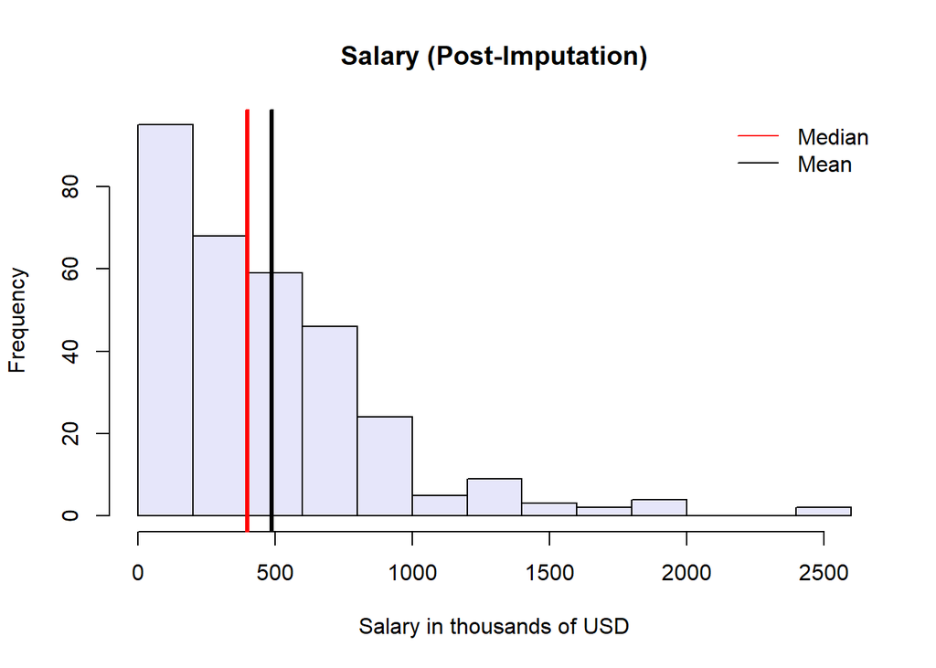

```r
hist(Hitters_clean$Salary,
     main = "Salary (Post-Imputation)",
     xlab = "Salary in thousands of USD",
     col = "lavender",
     breaks = 10)

abline(v = median(Hitters_clean$Salary), col = "red", lwd = 3)
abline(v = mean(Hitters_clean$Salary), col = "black", lwd = 3)

legend("topright",
       legend = c("Median", "Mean"),
       lty = 1,
       col = c("red", "black"),
       bty = "n")
```

```r
summary_stats <- data.frame(
  Mean = mean(Hitters_clean$Salary),
  SD = sd(Hitters_clean$Salary),
  Minimum = min(Hitters_clean$Salary),
  Maximum = max(Hitters_clean$Salary)
)

rownames(summary_stats) <- c("Salary")
summary_stats
```

```
##            Mean       SD Minimum Maximum
## Salary 487.1381 408.2169    67.5    2460
```

### Log-transformation of Salary

We decide to apply a log transformation to the salary variable as it helps to reduce the strong skew we saw in the original distribution. It pulls in the extreme high values and makes the overall shape more balanced and symmetric. This not only makes the data easier to work with but also makes more sense when we later group salaries into categories. As we can see from the print now the categories are pretty well balanced.

```r
# Log-transform Salary
Hitters$LogSalary <- log(Hitters$Salary)

# Create SalaryLevel
Hitters$SalaryLevel <- cut(Hitters$LogSalary,
                           breaks = quantile(Hitters$LogSalary, probs = c(0, 1/3, 2/3, 1), na.rm = TRUE),
                           labels = c("LowSalary", "MediumSalary", "HighSalary"),
                           include.lowest = TRUE)

# Check distribution
table(Hitters$SalaryLevel)
```

```
##
##    LowSalary MediumSalary   HighSalary
##          106          105          106
```

```r
Hitters$SalaryLevel <- as.factor(Hitters$SalaryLevel)
```

### Distribution of Log-Transformed Salary

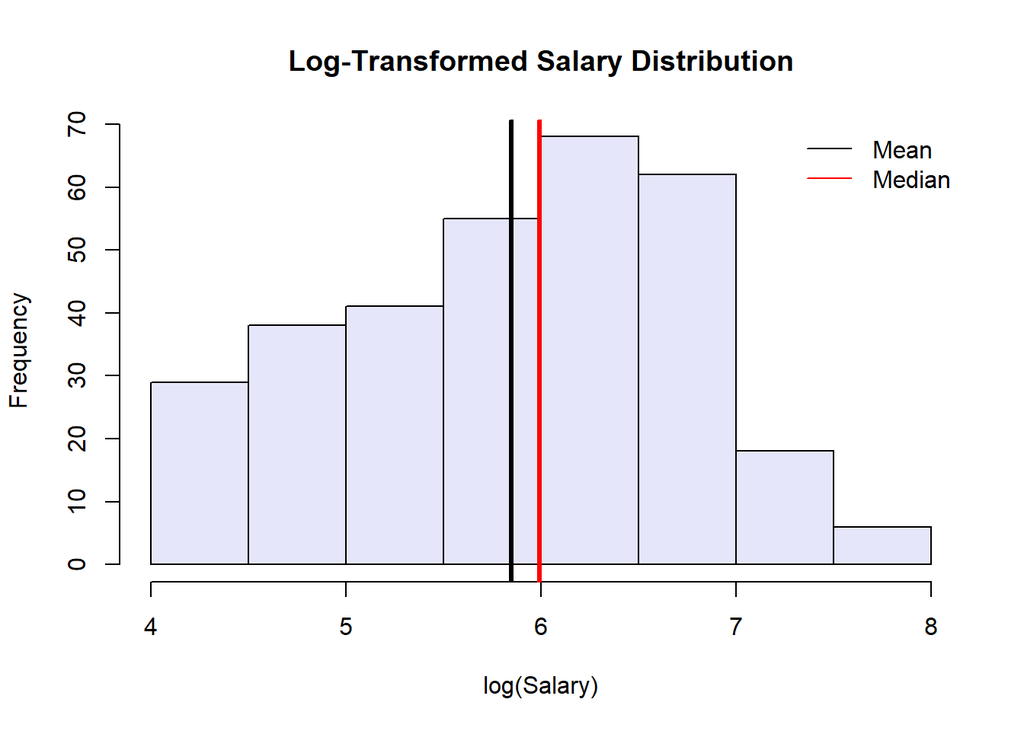

```r
# Log-Transformed Salary
hist(Hitters$LogSalary,
     main = "Log-Transformed Salary Distribution",
     xlab = "log(Salary)",
     col = "lavender",
     breaks = 10)

abline(v = mean(Hitters$LogSalary), col = "black", lwd = 3)
abline(v = median(Hitters$LogSalary), col = "red", lwd = 3)
legend("topright", legend = c("Mean", "Median"), col = c("black", "red"), lty = 1, bty = "n")
```

### Comparing distributions before and after scaling

The comparison between the two plots shows the effect of standardization on the numeric variables. Before scaling, many variables are right-skewed and differ greatly in scale, especially those related to career statistics (`CAtBat`, `CHits`, `CRuns`). After scaling, all variables are centered around zero with comparable spread. The shape of the distributions remains largely unchanged, as expected with standardization. This ensures that each variable contributes fairly to the multinomial logistic regression model without being penalized or overly weighted due to its original magnitude.

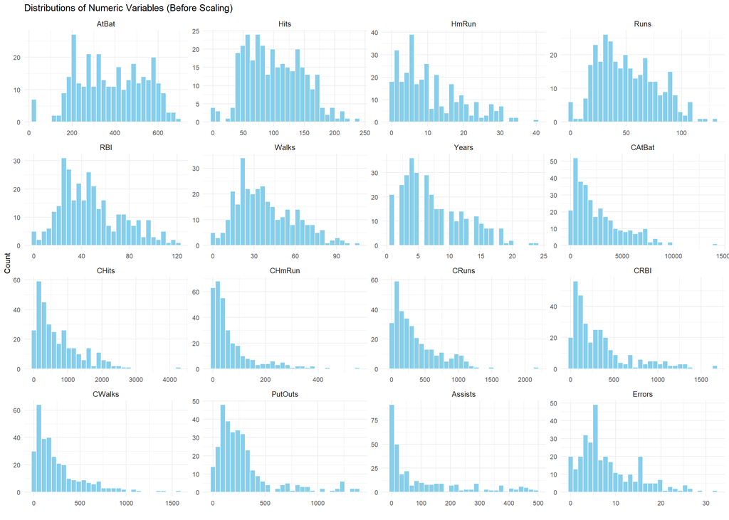

```r
num_vars <- sapply(Hitters, is.numeric)
exclude <- c("Salary", "LogSalary")
vars_to_plot <- setdiff(names(Hitters)[num_vars], exclude)

# Save original values for plotting
Hitters_before_scaling <- Hitters
Hitters_long_before <- melt(Hitters_before_scaling[, vars_to_plot])

# Histograms
ggplot(Hitters_long_before, aes(x = value)) +
  geom_histogram(bins = 30, fill = "skyblue", color = "white") +
  facet_wrap(~variable, scales = "free", ncol = 4) +
  labs(title = "Distributions of Numeric Variables (Before Scaling)",
       x = "", y = "Count") +
  theme_minimal() +
  theme(strip.text = element_text(size = 10))
```

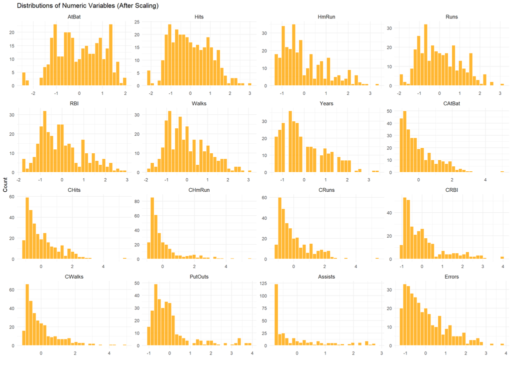

```r
num_vars <- sapply(Hitters_clean, is.numeric)
exclude <- c("Salary", "LogSalary")
vars_to_scale <- setdiff(names(Hitters_clean)[num_vars], exclude)
vars_to_plot <- vars_to_scale

# Apply standardization
Hitters_scaled <- Hitters_clean
Hitters_scaled[, vars_to_scale] <- scale(Hitters_scaled[, vars_to_scale])

Hitters_long_after <- melt(Hitters_scaled[, vars_to_plot])

# Histograms
ggplot(Hitters_long_after, aes(x = value)) +
  geom_histogram(bins = 30, fill = "orange", color = "white", alpha = 0.8) +
  facet_wrap(~variable, scales = "free", ncol = 4) +
  labs(title = "Distributions of Numeric Variables (After Scaling)",
       x = "", y = "Count") +
  theme_minimal() +
  theme(strip.text = element_text(size = 10))
```

## c. Encoding Salary variable

We weren’t satisfied with a subset division in 3 different *Salary Levels* so we decide to use a **clustering method** to outline the correct number of levels. After playing around with the value of *K*, we find in 5 the right choice. As you may notice, the `SalaryLevel5 - High` is unbalanced with respect to the other levels: this perfectly aligns with previous observations. 🤑

```r
set.seed(123)

# Perform K-means clustering on log-salary
clusters <- kmeans(Hitters$LogSalary, centers = 5)

Hitters$SalaryClusterRaw <- as.factor(clusters$cluster)

# Compute mean log-salary
cluster_means <- aggregate(Hitters$LogSalary,
                           by = list(Cluster = Hitters$SalaryClusterRaw),
                           FUN = mean)

# Order clusters
ordered_clusters <- cluster_means$Cluster[order(cluster_means$x)]

# Assign final labels
Hitters_scaled$SalaryLevel5 <- factor(Hitters$SalaryClusterRaw,
                               levels = ordered_clusters,
                               labels = c("Low", "MediumLow", "Medium", "MediumHigh", "High"))

# Check class balance
table(Hitters_scaled$SalaryLevel5)
```

```
##
##        Low  MediumLow     Medium MediumHigh       High
##         67         72         70         84         24
```

## d. Visual inspection

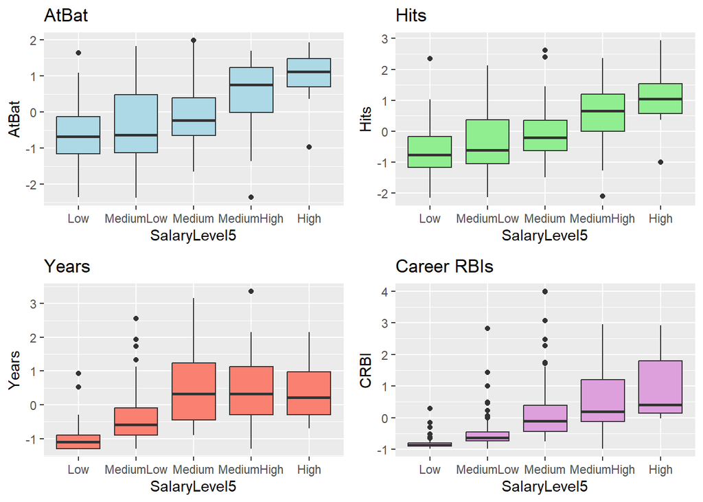

```r
Hitters_scaled$SalaryLevel5 <- factor(Hitters_scaled$SalaryLevel5,
                                levels = c("Low", "MediumLow", "Medium", "MediumHigh", "High"))

# Boxplots
g1 <- ggplot(Hitters_scaled, aes(x = SalaryLevel5, y = AtBat)) + geom_boxplot(fill = "lightblue") + ggtitle("AtBat")
g2 <- ggplot(Hitters_scaled, aes(x = SalaryLevel5, y = Hits)) + geom_boxplot(fill = "lightgreen") + ggtitle("Hits")
g3 <- ggplot(Hitters_scaled, aes(x = SalaryLevel5, y = Years)) + geom_boxplot(fill = "salmon") + ggtitle("Years")
g4 <- ggplot(Hitters_scaled, aes(x = SalaryLevel5, y = CRBI)) + geom_boxplot(fill = "plum") + ggtitle("Career RBIs")
grid.arrange(g1, g2, g3, g4, ncol = 2)
```

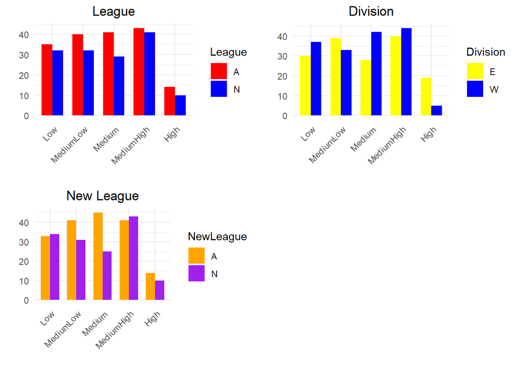

```r
# Bar plots
g_league <- ggplot(Hitters_scaled, aes(x = SalaryLevel5, fill = League)) +
  geom_bar(position = "dodge", width = 0.7) +
  labs(title = "League", x = "", y = "") +
  scale_fill_manual(values = c("red", "blue")) +
  theme_minimal() +
  theme(axis.text.x = element_text(angle = 45, hjust = 1),
        plot.title = element_text(hjust = 0.5))

g_division <- ggplot(Hitters_scaled, aes(x = SalaryLevel5, fill = Division)) +
  geom_bar(position = "dodge", width = 0.7) +
  labs(title = "Division", x = "", y = "") +
  scale_fill_manual(values = c("yellow", "blue")) +
  theme_minimal() +
  theme(axis.text.x = element_text(angle = 45, hjust = 1),
        plot.title = element_text(hjust = 0.5))

g_newleague <- ggplot(Hitters_scaled, aes(x = SalaryLevel5, fill = NewLeague)) +
  geom_bar(position = "dodge", width = 0.7) +
  labs(title = "New League", x = "", y = "") +
  scale_fill_manual(values = c("orange", "purple")) +
  theme_minimal() +
  theme(axis.text.x = element_text(angle = 45, hjust = 1),
        plot.title = element_text(hjust = 0.5))

grid.arrange(g_league, g_division, g_newleague, nrow = 2)
```

### Chi-square testing

To formally assess whether categorical predictors are associated with `SalaryLevel5`, we conduct chi-squared tests. Results indicate that only `Division` is significantly associated with salary level (Chi-squared = 12.31, df = 4, p = 0.015), suggesting that the division a player belongs to may influence their salary. By contrast, `League` and `NewLeague` did not show statistically significant associations (p > 0.05), consistent with the more uniform distributions seen in the bar plots. Among categorical variables, `Division` appears to have a non-uniform distribution across salary levels. `League` and `NewLeague` show more uniform distributions and may have less predictive power.

```r
chisq_league <- chisq.test(table(Hitters_scaled$SalaryLevel5, Hitters$League))

chisq_division <- chisq.test(table(Hitters_scaled$SalaryLevel5, Hitters$Division))

chisq_newleague <- chisq.test(table(Hitters_scaled$SalaryLevel5, Hitters$NewLeague))

chisq_league
```

```
##
##  Pearson's Chi-squared test
##
## data:  table(Hitters_scaled$SalaryLevel5, Hitters$League)
## X-squared = 1.1513, df = 4, p-value = 0.8861
```

```r
chisq_division
```

```
##
##  Pearson's Chi-squared test
##
## data:  table(Hitters_scaled$SalaryLevel5, Hitters$Division)
## X-squared = 12.313, df = 4, p-value = 0.01517
```

```r
chisq_newleague
```

```
##
##  Pearson's Chi-squared test
##
## data:  table(Hitters_scaled$SalaryLevel5, Hitters$NewLeague)
## X-squared = 4.8472, df = 4, p-value = 0.3033
```

Straightaway we see the presence of **strong positive correlations** among several performance-related statistics. For example, variables such as `AtBat`, `Hits`, `Runs`, and `Walks` are tightly connected, with correlation values often exceeding 0.9. This isn’t surprising because players who step up to the plate more frequently tend to score more runs and collect more hits and walks. However, from a modeling perspective, this signals **redundancy**: including all of them in the same model could introduce multicollinearity. Looking further, we notice a similar pattern among the **career stats**: `CRuns`, `CRBI`, `CWalks`, `CHits`, and `CAtBat` are almost perfectly correlated. This makes sense, as career totals grow hand-in-hand over time, but again, they likely lead to overlapping situations. Turning to the relationship with `Salary`, a handful of predictors exhibit **moderate positive associations** notably `RBI`, `Hits`, `HmRun`, and `Walks`.

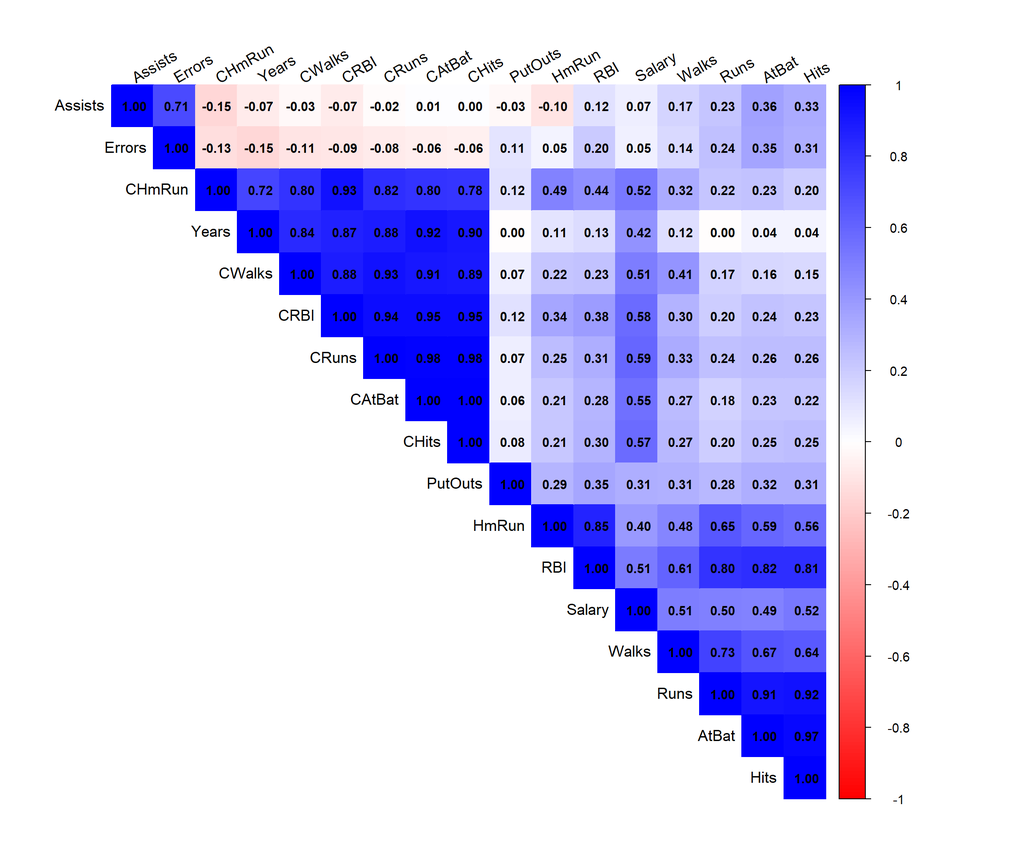

```r
num_vars <- sapply(Hitters_scaled, is.numeric)
cor_matrix <- cor(Hitters_scaled[, num_vars], use = "complete.obs")

# Correlation Matrix
corrplot(cor_matrix,
         method = "color",
         type = "upper",
         order = "hclust",
         addCoef.col = "black",
         number.cex = 0.9,
         tl.col = "black",
         tl.srt = 30,
         tl.cex = 1.1,
         cl.cex = 0.9,
         col = colorRampPalette(c("red", "white", "blue"))(200),
         mar = c(2, 2, 2, 2))
```

After the correlation matrix we decide to plot a couple more boxplots to look for other possible interesting insights. We notice that higher salary groups consistently display higher medians and wider ranges, particularly for career achievements, indicating their relevance as predictors. We do observe the presence of outliers but this can be explained by the nature of the dataset: in every sport there exists a stratum of elite players that introduce a gap with respect to their teammates and opponents. ⚾ 🏆 Therefore we decide to avoid any outliers managing…😁

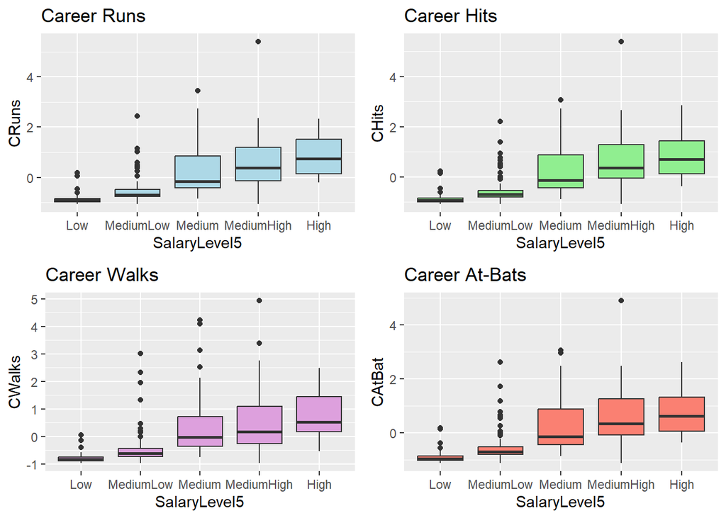

```r
## Boxplots
g1 <- ggplot(Hitters_scaled, aes(x = SalaryLevel5, y = CRuns)) +
  geom_boxplot(fill = "lightblue") + ggtitle("Career Runs")

g2 <- ggplot(Hitters_scaled, aes(x = SalaryLevel5, y = CHits)) +
  geom_boxplot(fill = "lightgreen") + ggtitle("Career Hits")

g3 <- ggplot(Hitters_scaled, aes(x = SalaryLevel5, y = CWalks)) +
  geom_boxplot(fill = "plum") + ggtitle("Career Walks")

g4 <- ggplot(Hitters_scaled, aes(x = SalaryLevel5, y = CAtBat)) +
  geom_boxplot(fill = "salmon") + ggtitle("Career At-Bats")

grid.arrange(g1, g2, g3, g4, ncol = 2)
```

## e. Fit the Multinomial Logistic Regression Model (Full Model)

Now that we’ve carefully prepared and explored our dataset, we’re ready to fit our first predictive model 😎. Given that our target variable `SalaryLevel5` is a categorical outcome with five levels, we use a **multinomial logistic regression** to model the relationship between a player’s performance stats and its salary category. We’ll start with a **full model** including all available predictors.

```r
library(nnet)

Hitters_clean$SalaryLevel5 <- Hitters_scaled$SalaryLevel5

# Fit multinomial logistic regression
full_model <- multinom(SalaryLevel5 ~ ., data = Hitters_clean, trace = TRUE)
# Summary output
summary(full_model)
```

```
## Call:
## multinom(formula = SalaryLevel5 ~ ., data = Hitters_clean, trace = TRUE)
##
## Coefficients:
##            (Intercept)      AtBat       Hits      HmRun     Runs        RBI
## MediumLow    -134.7449 -0.4393664  0.7218121 -2.5356607 1.802690  0.8672788
## Medium       -419.9457  0.2222959 -0.8589421  0.7808528 1.606090 -1.1006911
## MediumHigh   -913.7557  0.7654493 -1.2240257  2.5741947 1.452782 -2.6104991
## High        -1670.9949  1.7748927 -3.4919912  3.8919695 2.498339 -2.7327387
##                 Walks     Years     CAtBat      CHits     CHmRun      CRuns
## MediumLow  -0.5644552 -4.585143 0.34194132 -0.9463722 -0.7973676 -0.6728979
## Medium     -0.4562358 -7.617023 0.30512303 -0.7506258 -1.0355618 -0.7012632
## MediumHigh -0.7487593 -4.517269 0.26485949 -0.7853498 -1.8928958 -0.6841707
## High       -1.6758208  2.339377 0.02075283  0.6880709  0.6660674 -1.8405268
##                  CRBI      CWalks  LeagueN DivisionW     PutOuts      Assists
## MediumLow   0.1958146 0.002184458 21.44053  10.75537 -0.02470443 -0.069252131
## Medium      0.2329577 0.037424853 32.10091  12.10819 -0.04718240  0.049389466
## MediumHigh  0.6882758 0.104279646 55.91399  37.04660 -0.06893495 -0.001126175
## High       -0.4312802 0.328027801 87.37138 -35.14979 -0.12891595 -0.130430717
##               Errors    Salary NewLeagueN
## MediumLow  2.6057902 0.8953724  -37.98748
## Medium     0.9563224 1.7086263  -59.23155
## MediumHigh 0.8788757 2.3857082  -94.02360
## High       1.6418900 3.0089976  -39.80371
##
## Std. Errors:
##            (Intercept)     AtBat     Hits      HmRun      Runs        RBI
## MediumLow  0.033821251 0.4144292 1.851380 2.53014221 2.1809522 1.36020000
## Medium     0.001912289 0.6770847 0.138511 0.11610846 0.1291244 0.19619007
## MediumHigh 0.001131664 1.1563464 0.300270 0.14115305 0.2031272 0.30315552
## High       0.001196557 0.7681874 0.252471 0.01675217 0.1280300 0.07059751
##                 Walks       Years    CAtBat     CHits     CHmRun     CRuns
## MediumLow  0.83857241 1.951000733 0.1276685 0.6500527 1.65404772 0.8098078
## Medium     0.15145108 0.019116313 0.4561542 0.9176418 0.76747913 0.5804178
## MediumHigh 0.17017439 0.005630884 0.4547537 0.6517469 0.78366008 0.4979175
## High       0.06222099 0.005982825 2.8286769 0.9213452 0.03231145 0.4211887
##                 CRBI    CWalks     LeagueN   DivisionW    PutOuts    Assists
## MediumLow  1.0786787 0.4190472 0.199989348 0.298371598 0.02077616 0.11602414
## Medium     1.2125136 0.3796895 0.004506425 0.004265409 0.63352995 0.52476574
## MediumHigh 1.2588430 0.4989115 0.003863070 0.004089306 1.45493250 0.06923563
## High       0.2752145 0.2309408 0.001196515 0.001196557 0.40323868 0.02273424
##                 Errors    Salary  NewLeagueN
## MediumLow  1.874765094 0.2225651 0.199989347
## Medium     0.028913698 1.0286919 0.004678216
## MediumHigh 0.019231200 0.7149800 0.004030276
## High       0.004786313 0.8854603 0.001196515
##
## Residual Deviance: 0.3978922
## AIC: 168.3979
```

## f. Model evaluation

The appropriate error metric is the **misclassification rate**, which is calculated as:

$$\text{Misclassification Rate} = 1 - \left( \frac{\text{Number of Correct
Predictions}}{\text{Total Number of Predictions}} \right) = 1 -
\text{Accuracy}$$

This measure reflects the proportion of observations for which the model predicts the wrong salary category. A lower misclassification rate indicates better model performance.

### Select Random CV Method

Here, as requested, we select randomly an evaluation method among the ones proposed.

The seed is set to be the birthday of **R-senalofData$FrancescoCosta**.🍾🎂

```r
set.seed(10102004)
cv_methods <- c("1. Vanilla validation set", "2. LOO-CV",
                "3. K-fold CV (with K = 5)", "4. K-fold CV (with K = 10)")
sample(cv_methods, 1)
```

```
## [1] "4. K-fold CV (with K = 10)"
```

### Model Evaluation: K-fold CV (K = 10)

In **K-fold CV**, we split the data into **k equal parts**. The model is trained on **k-1 folds** and tested on the remaining one. This process repeats **k times**, each time using a different fold as the test set. The **average error** across all folds gives us an estimate of model performance. The model achieves a **moderate overall accuracy of around 55%**, performing decently. It classifies the lowest and highest salary levels relatively well but struggles with intermediate classes, particularly class 3. This suggests **some overlap in feature patterns across adjacent salary levels**, indicating room for improvement through feature refinement or alternative modeling approaches. 📉📉😣

```r
library(caret)

Hitters_cv <- Hitters_clean
Hitters_cv$SalaryLevel5 <- Hitters_clean$SalaryLevel5
Hitters_cv$Salary <- NULL  # Drop Salary to prevent leakage

set.seed(10102004)
n_folds <- 10
folds <- sample(rep(1:n_folds, length.out = nrow(Hitters_cv)))
fold_errors <- numeric(n_folds)

# Initialize vectors to collect predictions
true_labels <- c()
pred_labels <- c()

for (k in 1:n_folds) {
  # Split data
  train_data <- Hitters_cv[folds != k, ]
  test_data  <- Hitters_cv[folds == k, ]

  model_k <- multinom(SalaryLevel5 ~ ., data = train_data, trace = FALSE)
  preds <- predict(model_k, newdata = test_data)

  # Store predictions
  true_labels <- c(true_labels, test_data$SalaryLevel5)
  pred_labels <- c(pred_labels, preds)

  # Fold error
  fold_errors[k] <- mean(preds != test_data$SalaryLevel5)
}

# Final CV error
mean_k10_error <- mean(fold_errors)
mean_k10_error
```

```
## [1] 0.4478831
```

```r
# Confusion matrix
conf_matrix <- confusionMatrix(as.factor(pred_labels), as.factor(true_labels))
conf_matrix
```

```
## Confusion Matrix and Statistics
##
##           Reference
## Prediction  1  2  3  4  5
##          1 53 17  4  1  0
##          2 11 36 19 10  0
##          3  1 13 24 17  1
##          4  2  6 20 47  8
##          5  0  0  3  9 15
##
## Overall Statistics
##
##                Accuracy : 0.5521
##                  95% CI : (0.4955, 0.6077)
##     No Information Rate : 0.265
##     P-Value [Acc > NIR] : < 2.2e-16
##
##                   Kappa : 0.4262
##
##  Mcnemar's Test P-Value : NA
##
## Statistics by Class:
##
##                      Class: 1 Class: 2 Class: 3 Class: 4 Class: 5
## Sensitivity            0.7910   0.5000  0.34286   0.5595  0.62500
## Specificity            0.9120   0.8367  0.87045   0.8455  0.95904
## Pos Pred Value         0.7067   0.4737  0.42857   0.5663  0.55556
## Neg Pred Value         0.9421   0.8506  0.82375   0.8419  0.96897
## Prevalence             0.2114   0.2271  0.22082   0.2650  0.07571
## Detection Rate         0.1672   0.1136  0.07571   0.1483  0.04732
## Detection Prevalence   0.2366   0.2397  0.17666   0.2618  0.08517
## Balanced Accuracy      0.8515   0.6684  0.60665   0.7025  0.79202
```

### Model Evaluation: Vanilla Validation Set

In **Vanilla validation**, we randomly split the dataset into **two parts**: a **training set** and a **test set**. We train the model once on the training data and evaluate it on the test set. It’s quick and simple, but results can vary depending on the split. The vanilla model achieves an accuracy of **56.3%**, slightly better than the cross-validated model. It performs best on the **Low** and **High** salary classes (sensitivities of 93% and 80%, respectively), but struggles with **Medium** and **MediumLow**, reflecting moderate confusion among adjacent classes. Overall, the model shows acceptable performance with room for improvement, especially in distinguishing mid-range salary levels. 📉

```r
Hitters_vanilla <- Hitters_clean
Hitters_vanilla$SalaryLevel5 <- Hitters_clean$SalaryLevel5
Hitters_vanilla$Salary <- NULL

set.seed(10102004)
train_indices <- sample(1:nrow(Hitters_vanilla), size = 0.7 * nrow(Hitters_vanilla))
train_data <- Hitters_vanilla[train_indices, ]
test_data  <- Hitters_vanilla[-train_indices, ]

vanilla_model <- multinom(SalaryLevel5 ~ ., data = train_data, trace = FALSE)

# Predict on test set
vanilla_preds <- predict(vanilla_model, newdata = test_data)

# Compute misclassification rate
vanilla_error <- mean(vanilla_preds != test_data$SalaryLevel5)
vanilla_error
```

```
## [1] 0.4375
```

```r
# Confusion matrix
vanilla_conf_matrix <- confusionMatrix(
  as.factor(vanilla_preds),
  as.factor(test_data$SalaryLevel5)
)

vanilla_conf_matrix
```

```
## Confusion Matrix and Statistics
##
##             Reference
## Prediction   Low MediumLow Medium MediumHigh High
##   Low         14         4      1          1    0
##   MediumLow    1         7      9          1    0
##   Medium       0         2      8          4    0
##   MediumHigh   0         2      6         17    2
##   High         0         1      0          8    8
##
## Overall Statistics
##
##                Accuracy : 0.5625
##                  95% CI : (0.4575, 0.6636)
##     No Information Rate : 0.3229
##     P-Value [Acc > NIR] : 1.134e-06
##
##                   Kappa : 0.4465
##
##  Mcnemar's Test P-Value : NA
##
## Statistics by Class:
##
##                      Class: Low Class: MediumLow Class: Medium
## Sensitivity              0.9333          0.43750       0.33333
## Specificity              0.9259          0.86250       0.91667
## Pos Pred Value           0.7000          0.38889       0.57143
## Neg Pred Value           0.9868          0.88462       0.80488
## Prevalence               0.1562          0.16667       0.25000
## Detection Rate           0.1458          0.07292       0.08333
## Detection Prevalence     0.2083          0.18750       0.14583
## Balanced Accuracy        0.9296          0.65000       0.62500
##                      Class: MediumHigh Class: High
## Sensitivity                     0.5484     0.80000
## Specificity                     0.8462     0.89535
## Pos Pred Value                  0.6296     0.47059
## Neg Pred Value                  0.7971     0.97468
## Prevalence                      0.3229     0.10417
## Detection Rate                  0.1771     0.08333
## Detection Prevalence            0.2812     0.17708
## Balanced Accuracy               0.6973     0.84767
```

## g. Fit the Multinomial Logistic Regression Model (Reduced Model)

While our full model performs quite well, it includes all available predictors, some of which may be redundant or only marginally informative. In this section, we aim to simplify the model by selecting a **subset of the most relevant features**, with the goal of improving overall accuracy.  
We explore two different techniques: a **manual selection** of variables based on the correlation matrix and a **stepwise AIC-based selection**. We finally evaluate the reduced models using the same cross-validation strategies adopted earlier. Let’s see if less can be more! 🧠

### Feature Selection

We plot again the correlation matrix, including the *log-scaled salary variable* to identify possible redundancies of information given by highly correlated variables.

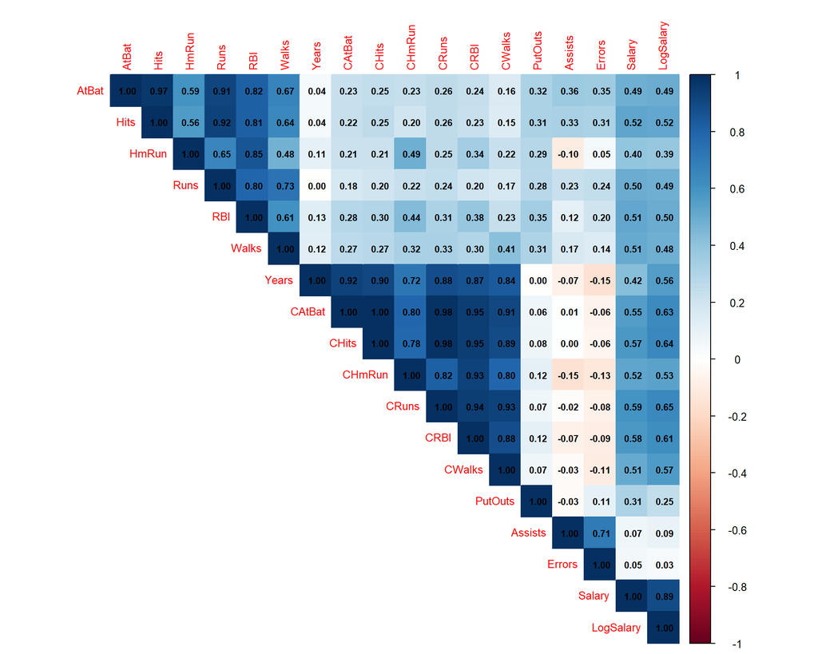

```r
Hitters_corr <- Hitters_clean
Hitters_corr$LogSalary <- log(Hitters_corr$Salary)

num_vars <- sapply(Hitters_corr, is.numeric)
corr_matrix <- cor(Hitters_corr[, num_vars], use = "complete.obs")

# Correlation Matrix
corrplot(corr_matrix, method = "color", type = "upper",
         addCoef.col = "black", tl.cex = 0.8, number.cex = 0.7,
         mar = c(0,0,1,0), diag = TRUE)
```

```r
# Create the reduced dataset from the clean version
Hitters_reduced <- Hitters_clean
Hitters_reduced$SalaryLevel5 <- Hitters_scaled$SalaryLevel5

# Define reduced formula with selected predictors
reduced_formula <- SalaryLevel5 ~ CRuns + CHmRun + Years + Walks + PutOuts +
                                 League + Division + NewLeague

str(Hitters_reduced[, all.vars(reduced_formula)])
```

```
## 'data.frame':    317 obs. of  9 variables:
##  $ SalaryLevel5: Factor w/ 5 levels "Low","MediumLow",..: 1 3 3 3 1 4 1 1 1 3 ...
##  $ CRuns       : int  30 321 224 828 48 501 30 41 32 702 ...
##  $ CHmRun      : int  1 69 63 225 12 19 1 0 6 90 ...
##  $ Years       : int  1 14 3 11 2 11 2 3 2 10 ...
##  $ Walks       : int  14 39 76 37 30 35 21 7 8 59 ...
##  $ PutOuts     : int  446 632 880 200 805 282 76 121 143 238 ...
##  $ League      : Factor w/ 2 levels "A","N": 1 2 1 2 2 1 2 1 2 1 ...
##  $ Division    : Factor w/ 2 levels "E","W": 1 2 2 1 1 2 1 2 2 1 ...
##  $ NewLeague   : Factor w/ 2 levels "A","N": 1 2 1 2 2 1 1 1 2 1 ...
```

### Fitting a reduced model

Looking at the results a few patterns emerge. For example, `CRuns` and `Walks` display **consistently positive coefficients across all salary levels**, indicating that players with more career runs or walks tend to be associated with higher salary categories. On the other hand, variables like `NewLeagueN` or `DivisionW` show mixed or even negative effects. The **standard errors** help us get a sense of reliability. Lastly, the **model’s AIC** stands at **690.77**, which, although higher than the full model’s AIC, is acceptable given the trade-off we’ve made: a model that is simpler, easier to explain, and less prone to *overfitting*.

```r
# Fit the reduced model on the full dataset
reduced_model <- multinom(reduced_formula, data = Hitters_reduced, trace = TRUE)
summary(reduced_model)
```

```
## Call:
## multinom(formula = reduced_formula, data = Hitters_reduced, trace = TRUE)
##
## Coefficients:
##            (Intercept)      CRuns       CHmRun      Years      Walks
## MediumLow    -2.626874 0.01121432  0.004124367  0.3824179 0.00572132
## Medium       -5.596442 0.01909642 -0.003179648  0.3734765 0.02655606
## MediumHigh   -5.839745 0.02340474 -0.001146775  0.1167118 0.03452590
## High         -7.723636 0.02991898  0.007354375 -0.5067528 0.05266632
##                 PutOuts  LeagueN   DivisionW NewLeagueN
## MediumLow  0.0001357689 1.229274 -0.42620496  -1.467990
## Medium     0.0007167004 2.177556  0.07123652  -2.664977
## MediumHigh 0.0012709297 1.261905 -0.29774962  -1.106751
## High       0.0029381897 1.841013 -1.70179004  -1.549420
##
## Std. Errors:
##            (Intercept)       CRuns     CHmRun     Years      Walks     PutOuts
## MediumLow    0.5510004 0.005307540 0.01609137 0.1341480 0.01372602 0.001023805
## Medium       0.6306727 0.005456529 0.01630297 0.1427997 0.01479816 0.001091606
## MediumHigh   0.5838427 0.005502717 0.01629092 0.1474324 0.01462991 0.001060086
## High         0.6338686 0.006036865 0.01672845 0.2439258 0.01744349 0.001193380
##              LeagueN DivisionW NewLeagueN
## MediumLow  0.5262908 0.4166761  0.5278850
## Medium     0.4809187 0.4855653  0.4849762
## MediumHigh 0.5240636 0.4910876  0.5203835
## High       0.3499741 0.7434472  0.3504886
##
## Residual Deviance: 618.7732
## AIC: 690.7732
```

### Evaluating the manually reduced model

Overall, after manually reducing the dataset we weren’t able to improve model accuracy leading to an even worse score for both evaluation methods.

```r
set.seed(10102004)
n_folds <- 10
folds <- sample(rep(1:n_folds, length.out = nrow(Hitters_reduced)))
fold_errors_red <- numeric(n_folds)

Hitters_reduced$Salary <- NULL

for (k in 1:n_folds) {
  train_data <- Hitters_reduced[folds != k, ]
  test_data  <- Hitters_reduced[folds == k, ]

  model_red <- multinom(reduced_formula, data = train_data, trace = FALSE)
  preds <- predict(model_red, newdata = test_data)

  # Misclassification rate
  fold_errors_red[k] <- mean(preds != test_data$SalaryLevel5)
}

mean_k10_error_reduced <- mean(fold_errors_red)
mean_k10_error_reduced
```

```
## [1] 0.4544355
```

```r
Hitters_red_vanilla <- Hitters_reduced
Hitters_red_vanilla$Salary <- NULL

set.seed(10102004)
train_idx_red <- sample(1:nrow(Hitters_red_vanilla), size = 0.7 * nrow(Hitters_red_vanilla))
train_data_red <- Hitters_red_vanilla[train_idx_red, ]
test_data_red  <- Hitters_red_vanilla[-train_idx_red, ]

# Fit and predict
model_red_vanilla <- multinom(reduced_formula, data = train_data_red, trace = FALSE)
preds_red_vanilla <- predict(model_red_vanilla, newdata = test_data_red)

# Misclassification rate
vanilla_error_red <- mean(preds_red_vanilla != test_data_red$SalaryLevel5)
vanilla_error_red
```

```
## [1] 0.4583333
```

### Trying a different approach

For our second technique, we adopt a **backward selection** which works as follows: the process begins with all predictors and at each step removes the one whose exclusion most improves the AIC. This iterative process continues until no further improvement is possible.

The second output shows the coefficients of the final model fitted on the selected variables. The model still includes strong predictors like:

- `Hits, HmRun, Runs, Walks`, all intuitively linked to performance.
- `Years`, a synonym for experience.
- `CRuns and CWalks`, cumulative stats that are particularly informative.
- `Division`, one of the only categorical variables retained.
- `Errors`, interestingly kept although not statistically significant.

The plot shows how the model improves step-by-step as we drop variables that don’t contribute meaningfully to the prediction of `SalaryLevel5`. We started with **all predictors** and ended up dropping 10 variables (`CRBI`, `CHmRun`, `CAtBat`, `CHits`, `League`, `NewLeague`, `Assists`, `RBI`, `AtBat`, and finally `PutOuts`). Each removal brought a consistent **decrease in AIC**, which confirms that these variables added noise rather than predictive power.

```r
library(VGAM)

Hitters_step <- Hitters_clean
Hitters_step$SalaryLevel5 <- Hitters_scaled$SalaryLevel5  # use clustered levels
Hitters_step$Salary <- NULL  # remove to avoid leakage

Hitters_step$SalaryLevel5 <- factor(Hitters_step$SalaryLevel5,
                                    levels = c("Low", "MediumLow", "Medium", "MediumHigh", "High"))

# Initial variable list and full model
predictors <- names(Hitters_step)[names(Hitters_step) != "SalaryLevel5"]
best_formula <- as.formula(paste("SalaryLevel5 ~", paste(predictors, collapse = " + ")))
best_model <- vglm(best_formula, family = multinomial, data = Hitters_step)
best_aic <- AIC(best_model)

# Store the AIC path
aic_path <- data.frame(Step = 0, Dropped = "None", AIC = best_aic)

improvement <- TRUE
step <- 1

while (improvement) {
  current_aics <- data.frame(Variable = predictors, AIC = NA)

  for (var in predictors) {
    trial_vars <- setdiff(predictors, var)
    trial_formula <- as.formula(paste("SalaryLevel5 ~", paste(trial_vars, collapse = " + ")))
    trial_model <- vglm(trial_formula, family = multinomial, data = Hitters_step)
    current_aics[current_aics$Variable == var, "AIC"] <- AIC(trial_model)
  }

  # Identify variable whose removal reduces AIC the most
  min_aic <- min(current_aics$AIC)
  best_drop <- current_aics$Variable[which.min(current_aics$AIC)]

  if (min_aic < best_aic) {
    # Update predictors and AIC
    predictors <- setdiff(predictors, best_drop)
    best_aic <- min_aic
    aic_path <- rbind(aic_path, data.frame(Step = step, Dropped = best_drop, AIC = best_aic))
    step <- step + 1
  } else {
    improvement <- FALSE
  }
}

# Final model
final_formula <- as.formula(paste("SalaryLevel5 ~", paste(predictors, collapse = " + ")))
final_model <- vglm(final_formula, family = multinomial, data = Hitters_step)

# Output AIC path and final model
print(aic_path)
```

```
##    Step   Dropped      AIC
## 1     0      None 701.9089
## 2     1      CRBI 694.4269
## 3     2    CHmRun 689.2067
## 4     3    CAtBat 683.5177
## 5     4     CHits 677.4814
## 6     5    League 674.2615
## 7     6 NewLeague 670.7113
## 8     7   Assists 667.8555
## 9     8       RBI 664.7318
## 10    9     AtBat 662.1767
## 11   10   PutOuts 660.2754
```

```r
summary(final_model)
```

```
##
## Call:
## vglm(formula = final_formula, family = multinomial, data = Hitters_step)
##
## Coefficients:
##                Estimate Std. Error z value Pr(>|z|)
## (Intercept):1 11.986809   2.339869   5.123 3.01e-07 ***
## (Intercept):2  8.827813   2.254250   3.916 9.00e-05 ***
## (Intercept):3  5.884606   2.212610   2.660  0.00782 **
## (Intercept):4  4.601949   2.109043   2.182  0.02911 *
## Hits:1        -0.016156   0.024017  -0.673  0.50115
## Hits:2        -0.062062   0.019770  -3.139  0.00169 **
## Hits:3        -0.033252   0.017810  -1.867  0.06189 .
## Hits:4        -0.003413   0.015989  -0.213  0.83096
## HmRun:1       -0.122458   0.053623  -2.284  0.02239 *
## HmRun:2       -0.102413   0.046662  -2.195  0.02818 *
## HmRun:3       -0.133978   0.044743  -2.994  0.00275 **
## HmRun:4       -0.099109   0.041077  -2.413  0.01583 *
## Runs:1         0.009836   0.052242   0.188  0.85066
## Runs:2         0.127666   0.040815   3.128  0.00176 **
## Runs:3         0.080312   0.036604   2.194  0.02823 *
## Runs:4         0.020697   0.032048   0.646  0.51841
## Walks:1       -0.057417   0.040008  -1.435  0.15125
## Walks:2       -0.127059   0.030025  -4.232 2.32e-05 ***
## Walks:3       -0.086709   0.027994  -3.097  0.00195 **
## Walks:4       -0.059764   0.025399  -2.353  0.01862 *
## Years:1        0.229434   0.292301   0.785  0.43250
## Years:2        0.686911   0.250315   2.744  0.00607 **
## Years:3        0.672641   0.242198   2.777  0.00548 **
## Years:4        0.418276   0.224941   1.859  0.06296 .
## CRuns:1       -0.018086   0.009988      NA       NA
## CRuns:2       -0.027602   0.005175  -5.334 9.60e-08 ***
## CRuns:3       -0.016791   0.004188  -4.009 6.10e-05 ***
## CRuns:4       -0.009276   0.003638  -2.550  0.01079 *
## CWalks:1      -0.015962   0.014258  -1.120  0.26291
## CWalks:2       0.015298   0.004778   3.202  0.00137 **
## CWalks:3       0.009022   0.003754   2.403  0.01626 *
## CWalks:4       0.005346   0.003317   1.612  0.10702
## DivisionW:1    1.626193   0.800552   2.031  0.04222 *
## DivisionW:2    1.321370   0.729971   1.810  0.07027 .
```

[output cut: 8 more lines]

```
##
## Names of linear predictors: log(mu[,1]/mu[,5]), log(mu[,2]/mu[,5]),
## log(mu[,3]/mu[,5]), log(mu[,4]/mu[,5])
##
## Residual deviance: 580.2754 on 1228 degrees of freedom
##
## Log-likelihood: -290.1377 on 1228 degrees of freedom
##
## Number of Fisher scoring iterations: 8
##
## Warning: Hauck-Donner effect detected in the following estimate(s):
## 'CRuns:1', 'CRuns:2'
##
##
## Reference group is level  5  of the response
```

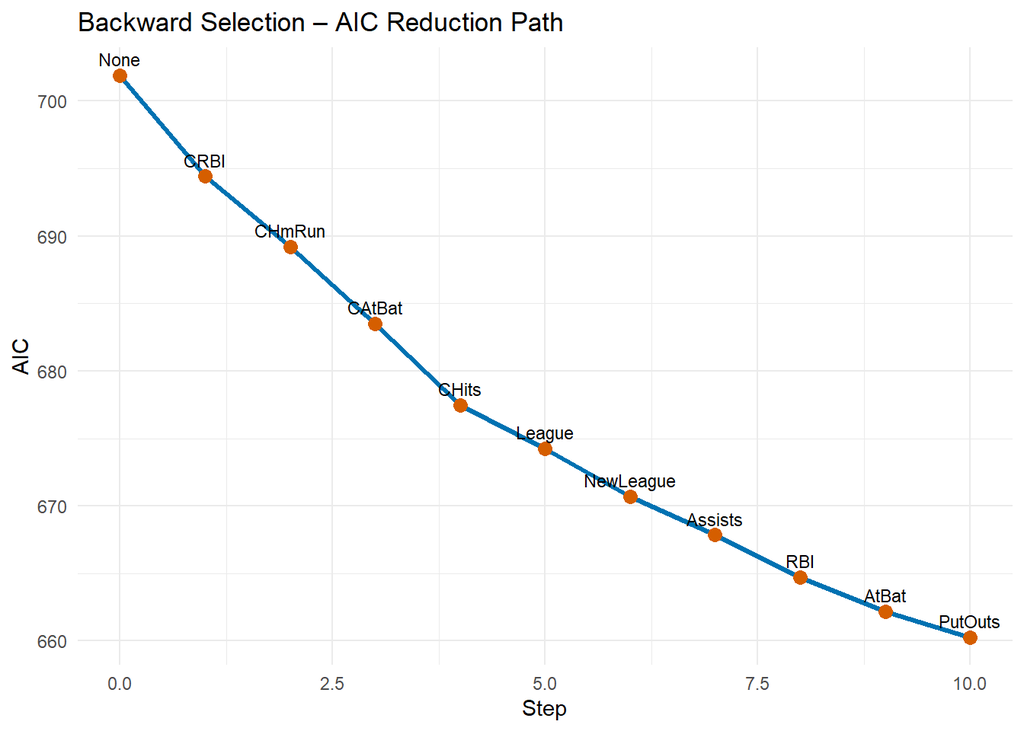

```r
# AIC reduction path
ggplot(aic_path, aes(x = Step, y = AIC)) +
  geom_line(color = "#0072B2", linewidth = 1.2) +
  geom_point(size = 3, color = "#D55E00") +
  geom_text(aes(label = Dropped), vjust = -0.7, size = 3) +
  labs(title = "Backward Selection – AIC Reduction Path",
       x = "Step", y = "AIC") +
  theme_minimal()
```

### K-fold CV

Finally, we test the stepwise reduced model with K-fold CV and we notice that it slightly improves, approaching a **60% Accuracy score**. 📈📈😊

```r
final_predictors <- all.vars(final_formula)[-1]

Hitters_eval <- Hitters_clean
Hitters_eval$SalaryLevel5 <- Hitters_scaled$SalaryLevel5
Hitters_eval$Salary <- NULL

set.seed(10102004)
n_folds <- 10
folds <- sample(rep(1:n_folds, length.out = nrow(Hitters_eval)))
fold_errors_final <- numeric(n_folds)

num_vars <- sapply(Hitters_eval, is.numeric)
exclude <- c("Salary", "LogSalary")
vars_to_scale <- intersect(final_predictors, names(Hitters_eval)[num_vars])

for (k in 1:n_folds) {
  train_data <- Hitters_eval[folds != k, ]
  test_data  <- Hitters_eval[folds == k, ]

  for (var in vars_to_scale) {
    mean_train <- mean(train_data[[var]])
    sd_train   <- sd(train_data[[var]])
    train_data[[var]] <- (train_data[[var]] - mean_train) / sd_train
    test_data[[var]]  <- (test_data[[var]] - mean_train) / sd_train
  }

  model_k <- multinom(final_formula, data = train_data, trace = FALSE)
  preds <- predict(model_k, newdata = test_data)
  fold_errors_final[k] <- mean(preds != test_data$SalaryLevel5)
}

mean_k10_error_final <- mean(fold_errors_final)
mean_k10_error_final
```

```
## [1] 0.4198589
```

### Vanilla Validation

Unfortunately, even with a different approach the Vanilla Validation method doesn’t bless us with better results. 😭

```r
set.seed(10102004)
train_idx_final <- sample(1:nrow(Hitters_eval), size = 0.7 * nrow(Hitters_eval))
train_data_final <- Hitters_eval[train_idx_final, ]
test_data_final  <- Hitters_eval[-train_idx_final, ]

for (var in vars_to_scale) {
  mean_train <- mean(train_data_final[[var]])
  sd_train   <- sd(train_data_final[[var]])
  train_data_final[[var]] <- (train_data_final[[var]] - mean_train) / sd_train
  test_data_final[[var]]  <- (test_data_final[[var]] - mean_train) / sd_train
}

# Fit and predict
model_vanilla_final <- multinom(final_formula, data = train_data_final, trace = FALSE)
preds_vanilla_final <- predict(model_vanilla_final, newdata = test_data_final)

# Misclassification rate
vanilla_error_final <- mean(preds_vanilla_final != test_data_final$SalaryLevel5)
vanilla_error_final
```

```
## [1] 0.4583333
```

## Conclusions

In the end we notice that all models hovered around a **40–45% misclassification rate**, meaning that more than half the salary level predictions are correct. In particular:

- The **Full Model** offers solid baseline performance but is potentially overfitting.
- The **Reduced Model** shows comparable results with fewer variables
- The **Backward Stepwise Model** gives us a nice middle ground, achieving better accuracy while offering a data-driven path to variable selection.

While none of the models achieve very high predictive accuracy, this is understandable considering the complexity of salary dynamics in professional sports, which are likely influenced by many unobserved factors like *fame*, *marketability*, *contract history*. Nevertheless, the models we built perform significantly better than the baseline, and offer meaningful insights into which performance metrics tend to correlate with higher salaries. This project highlights the trade-offs between model complexity, interpretability, and performance. Finally, it demonstrates the value of model selection techniques in improving predictive accuracy without unnecessary complication.

```r
model_comparison <- data.frame(
  Model_Version = c("Full Model", "Full Model",
                   "Reduced Model", "Reduced Model",
                   "Backward Stepwise", "Backward Stepwise"),
  Validation_Method = c("10-fold CV", "Vanilla Validation",
                       "10-fold CV", "Vanilla Validation",
                       "10-fold CV", "Vanilla Validation"),
  Misclassification_Rate = c(mean_k10_error,
                            vanilla_error,
                            mean_k10_error_reduced,
                            vanilla_error_red,
                            mean_k10_error_final,
                            vanilla_error_final)
)

# Display the table
knitr::kable(model_comparison, caption = "Model Performance Comparison")
```

Model Performance Comparison

| Model_Version | Validation_Method | Misclassification_Rate |
| --- | --- | --- |
| Full Model | 10-fold CV | 0.4478831 |
| Full Model | Vanilla Validation | 0.4375000 |
| Reduced Model | 10-fold CV | 0.4544355 |
| Reduced Model | Vanilla Validation | 0.4583333 |
| Backward Stepwise | 10-fold CV | 0.4198589 |
| Backward Stepwise | Vanilla Validation | 0.4583333 |